# Fisseha Berhane, PhD

#### Data Scientist

443-970-2353 fisseha@jhu.edu CV Resume

[figure not shown]

# Data Ingestion to a Hadoop Data Lake with Jupyter

Jupyter is a web-based notebook which is used for data exploration, visualization, sharing and collaboration. It is an ideal environment for experimenting with different ideas and/or datasets. We can start with vague ideas and in Jupyter we can crystallize, after various experiments, our ideas for building our projects. It can also be used for staging data from a data lake to be used by BI and other tools. Jupyter supports more than 40 programming languages including Python, R, Scala, and Julia.

In this blog post, we will see how to use Jupyter to download data from the web and ingest the data to Hadoop Distributed File System (HDFS). Finally, we will explore our data in HDFS using Spark and create simple visualization. We will use Bay Area Bike Share's trip data from [this website](http://www.bayareabikeshare.com/open-data).

If you don't have a Hadoop cluster, you can download and deploy the [Hortonworks Sandbox](http://hortonworks.com/downloads/#sandbox). It is a nice environment to practice the Hadoop ecosystem components and Spark. You can install Jupyter following [this](http://simnotes.github.io/blog/installing-jupyter-on-hdp-4/) tutorial.

First, let's use the [os](https://docs.python.org/2/library/os.html) module from Python to create a local directory.

```python
import os
os.chdir("/home")   # change to /home
```

```python
os.getcwd()        # checking that we have changed to home directory
```

```
'/home'
```

We will create a local directory called bike_share to download our data to.

```python
if not os.path.exists(r'/home/bike_share'): #  if the directory does not
    os.makedirs(r'/home/bike_share')        #  exist create it
```

```python
os.chdir(r'/home/bike_share')     # changing to "bike_share" directory
```

```python
os.getcwd()      # Are we in the bike_share directory?
```

```
'/home/bike_share'
```

```python
! helps us to run a shell command
```

```python
! pwd        # checking the working directory is the bike_share directory
```

```
/home/bike_share
```

```python
! ls    # list files and folders in bike_share directory
        # actually, the directory is empty at this time
```

### Download data

Let's download Bay Area Bike Share's trip data from [this website](http://www.bayareabikeshare.com/open-data).

Let's use the Shell Interpreter by adding **!** to download the data using *wget*

As you can see from the [website](http://www.bayareabikeshare.com/open-data), there are two bike share data sets.

- (August 2013 - August 2014)
- (September 2014 - August 2015)

  Let's download the first one.

```python
! wget https://s3.amazonaws.com/babs-open-data/babs_open_data_year_1.zip
```

```
--2016-08-10 17:31:21--  https://s3.amazonaws.com/babs-open-data/babs_open_data_year_1.zip
Resolving s3.amazonaws.com... 54.231.16.136
Connecting to s3.amazonaws.com|54.231.16.136|:443... connected.
HTTP request sent, awaiting response... 200 OK
Length: 84402747 (80M) [application/zip]
Saving to: “babs_open_data_year_1.zip”

100%[======================================>] 84,402,747  4.34M/s   in 17s

2016-08-10 17:31:39 (4.73 MB/s) - “babs_open_data_year_1.zip” saved [84402747/84402747]
```

Now, let's see if the data has been downloaded.

```python
! ls
```

```
babs_open_data_year_1.zip
```

Great! Now, let's unzip it.

```python
! unzip babs_open_data_year_1.zip
```

```
Archive:  babs_open_data_year_1.zip
   creating: 201402_babs_open_data/
  inflating: 201402_babs_open_data/201402_station_data.csv
  inflating: 201402_babs_open_data/201402_status_data.csv
  inflating: 201402_babs_open_data/201402_trip_data.csv
  inflating: 201402_babs_open_data/201402_weather_data.csv
  inflating: 201402_babs_open_data/README.txt
   creating: 201408_babs_open_data/
  inflating: 201408_babs_open_data/201408_station_data.csv
  inflating: 201408_babs_open_data/201408_status_data.csv
  inflating: 201408_babs_open_data/201408_trip_data.csv
  inflating: 201408_babs_open_data/201408_weather_data.csv
  inflating: 201408_babs_open_data/README.txt
```

Now, let's see the files and folders.

```python
! ls
```

```
201402_babs_open_data  201408_babs_open_data  babs_open_data_year_1.zip
```

Let's remove the zipped file since we do not want it anymore.

```python
! rm -f *.zip
```

```python
! ls
```

```
201402_babs_open_data  201408_babs_open_data
```

Size of downloaded data:

```python
! du -h
```

```
611M	./201402_babs_open_data
643M	./201408_babs_open_data
1.3G	.
```

Now, let's see the contents of each folder.

```python
! ls 201402_babs_open_data/
```

```
201402_station_data.csv  201402_trip_data.csv	  README.txt
201402_status_data.csv	 201402_weather_data.csv
```

```python
! ls 201408_babs_open_data/
```

```
201408_station_data.csv  201408_trip_data.csv	  README.txt
201408_status_data.csv	 201408_weather_data.csv
```

### Ingest data to Hadoop Distributed File System (HDFS)

#### Create directory

```python
! hadoop fs -mkdir /bike_data
```

Let's list the HDFS directories and check if "bike_data" exists.

```python
! hadoop fs -ls /
```

```
Found 12 items
drwxrwxrwx   - yarn   hadoop          0 2016-03-14 14:19 /app-logs
drwxr-xr-x   - hdfs   hdfs            0 2016-03-14 14:25 /apps
drwxr-xr-x   - yarn   hadoop          0 2016-03-14 14:19 /ats
drwxr-xr-x   - root   hdfs            0 2016-08-10 18:27 /bike_data
drwxr-xr-x   - hdfs   hdfs            0 2016-03-14 14:50 /demo
drwxr-xr-x   - hdfs   hdfs            0 2016-03-14 14:19 /hdp
drwxr-xr-x   - mapred hdfs            0 2016-03-14 14:19 /mapred
drwxrwxrwx   - mapred hadoop          0 2016-03-14 14:19 /mr-history
drwxr-xr-x   - hdfs   hdfs            0 2016-03-14 14:42 /ranger
drwxrwxrwx   - spark  hadoop          0 2016-08-10 17:28 /spark-history
drwxrwxrwx   - hdfs   hdfs            0 2016-03-14 14:31 /tmp
drwxr-xr-x   - hdfs   hdfs            0 2016-03-14 14:33 /user
```

#### Put data to the directory

```python
! hadoop fs -put * /bike_data
```

Once we have ingested our data to HDFS, let's remove the bike data from the local directory.

```python
! rm -rf *
```

###### Now, let's check if our data has been ingested.

```python
! hadoop fs -ls  /bike_data
```

```
Found 2 items
drwxr-xr-x   - root hdfs          0 2016-08-10 18:29 /bike_data/201402_babs_open_data
drwxr-xr-x   - root hdfs          0 2016-08-10 18:29 /bike_data/201408_babs_open_data
```

Great, our data has been ingested. Now, let's use Spark and explore the data.

Let's open 201408_status_data.csv which has approx. 18 million records.

```python
from pyspark.sql import SQLContext
sqlContext = HiveContext(sc)
```

```python
status08 = sqlContext.read.format('com.databricks.spark.csv').\
options(header='true', inferSchema='true').\
load("hdfs://sandbox.hortonworks.com/bike_data/201408_babs_open_data/201408_status_data.csv")
```

Let's see number of records in the data.

```python
print status08.count()
```

```
18342210
```

So, we can see that the data has more than 18 million observations.

What about the schema?

```python
status08.printSchema()
```

```
root
 |-- station_id: integer (nullable = true)
 |-- bikes_available: integer (nullable = true)
 |-- docks_available: integer (nullable = true)
 |-- time: string (nullable = true)
```

```python
status08.select("*").show(truncate=False)
```

```
+----------+---------------+---------------+-------------------+
|station_id|bikes_available|docks_available|time               |
+----------+---------------+---------------+-------------------+
|2         |12             |15             |2014-03-01 00:00:02|
|2         |12             |15             |2014-03-01 00:01:03|
|2         |12             |15             |2014-03-01 00:02:03|
|2         |12             |15             |2014-03-01 00:03:02|
|2         |12             |15             |2014-03-01 00:04:03|
|2         |12             |15             |2014-03-01 00:05:02|
|2         |12             |15             |2014-03-01 00:06:03|
|2         |12             |15             |2014-03-01 00:07:02|
|2         |13             |14             |2014-03-01 00:08:03|
|2         |13             |14             |2014-03-01 00:09:02|
|2         |13             |14             |2014-03-01 00:10:03|
|2         |13             |14             |2014-03-01 00:11:03|
|2         |13             |14             |2014-03-01 00:12:02|
|2         |13             |14             |2014-03-01 00:13:02|
|2         |13             |14             |2014-03-01 00:14:02|
|2         |13             |14             |2014-03-01 00:15:02|
|2         |13             |14             |2014-03-01 00:16:03|
|2         |13             |14             |2014-03-01 00:17:03|
|2         |13             |14             |2014-03-01 00:18:03|
|2         |13             |14             |2014-03-01 00:19:02|
+----------+---------------+---------------+-------------------+
only showing top 20 rows
```

Let's change the last column from string to time format so that we can do analysis on monthly basis.

```python
from datetime import datetime
from pyspark.sql.functions import col,udf, unix_timestamp
from pyspark.sql.types import DateType
```

Let's create a user defined function that converts that last column from string to date and time.

```python
myfunc =  udf (lambda x: datetime.strptime(x, '%Y-%m-%d %H:%M:%S'), DateType())
```

```python
status_df = status08.withColumn('Date_and_Time', myfunc(col('time'))).drop('time')
```

```python
status_df.printSchema()
```

```
root
 |-- station_id: integer (nullable = true)
 |-- bikes_available: integer (nullable = true)
 |-- docks_available: integer (nullable = true)
 |-- Date_and_Time: date (nullable = true)
```

```python
from pyspark.sql.functions import dayofyear
```

```python
day_to_bikes_available = status_df.select(status_df['bikes_available'],\
                                          dayofyear(status_df['Date_and_Time']).alias('day'))

day_to_bikes_available_df = day_to_bikes_available.groupBy('day').max('bikes_available').\
                                  alias('Count')

day_to_bikes_available_df.show()
```

```
+---+--------------------+
|day|max(bikes_available)|
+---+--------------------+
|231|                  27|
|232|                  23|
|233|                  24|
|234|                  26|
|235|                  23|
|236|                  23|
|237|                  25|
|238|                  23|
|239|                  27|
|240|                  27|
|241|                  27|
|242|                  23|
|243|                  27|
| 60|                  22|
| 61|                  21|
| 62|                  27|
| 63|                  24|
| 64|                  25|
| 65|                  27|
| 66|                  27|
+---+--------------------+
only showing top 20 rows
```

```python
days = day_to_bikes_available_df.map(lambda r:r[0]).collect()

bikes_available = day_to_bikes_available_df.map(lambda r:r[1]).collect()
```

```python
import matplotlib.pyplot as plt
```

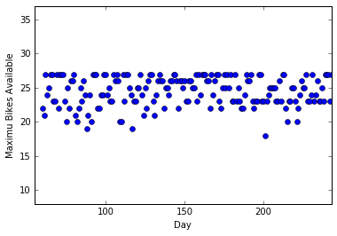

```python
plt.plot(days,bikes_available, 'bo')
plt.axis([min(days)-5, max(days), min(bikes_available)-10, max(bikes_available)+10])
plt.xlabel('Day')
plt.ylabel('Maximu Bikes Available')
plt.axhline(linewidth=3, color='#999999')
plt.axvline(linewidth=2, color='#999999')
plt.show()
```

In this post, we saw how to fetch data from the web, ingested it to Hadoop Distributed File System (HDFS) and did some data transformation using Spark and visualization using Matplot, Python's plotting library. We used Jupyter, a great data science notebook, to perform all the tasks.

[comments powered by Disqus](http://disqus.com)